# Risk Factor Analysis

## Outcome Variable

**Outcome Variable:** whz

## Predictor Variables

**Intervention Variable:** earlybf

**Adjustment Set:**

- arm
- sex
- W_mage
- meducyrs
- feducyrs
- hhwealth_quart
- hfoodsec
- W_mhtcm
- W_mwtkg
- W_mbmi
- vagbrth
- W_gagebrth
- W_birthwt
- W_birthlen
- W_nrooms
- W_nchldlt5
- brthmon
- W_parity
- impfloor
- impsan
- safeh20
- delta_W_mage
- delta_meducyrs
- delta_feducyrs
- delta_hhwealth_quart
- delta_hfoodsec
- delta_W_mhtcm
- delta_W_mwtkg
- delta_W_mbmi
- delta_vagbrth
- delta_W_gagebrth
- delta_W_birthwt
- delta_W_birthlen
- delta_W_nrooms
- delta_W_nchldlt5
- delta_brthmon
- delta_W_parity
- delta_impfloor
- delta_impsan
- delta_safeh20

## Stratifying Variables

The analysis was stratified on these variable(s):

- agecat
- studyid
- country

## Data Summary

| agecat | studyid | country | earlybf | n_cell | n | outcome_variable |
| --- | --- | --- | --- | --- | --- | --- |
| Birth | EE | PAKISTAN | 1 | 36 | 170 | whz |
| Birth | EE | PAKISTAN | 0 | 134 | 170 | whz |
| Birth | GMS-Nepal | NEPAL | 1 | 171 | 586 | whz |
| Birth | GMS-Nepal | NEPAL | 0 | 415 | 586 | whz |
| Birth | JiVitA-3 | BANGLADESH | 1 | 105 | 17943 | whz |
| Birth | JiVitA-3 | BANGLADESH | 0 | 17838 | 17943 | whz |
| Birth | JiVitA-4 | BANGLADESH | 1 | 1624 | 2396 | whz |
| Birth | JiVitA-4 | BANGLADESH | 0 | 772 | 2396 | whz |
| Birth | MAL-ED | BANGLADESH | 1 | 140 | 214 | whz |
| Birth | MAL-ED | BANGLADESH | 0 | 74 | 214 | whz |
| Birth | MAL-ED | BRAZIL | 1 | 26 | 62 | whz |
| Birth | MAL-ED | BRAZIL | 0 | 36 | 62 | whz |
| Birth | MAL-ED | INDIA | 1 | 31 | 44 | whz |
| Birth | MAL-ED | INDIA | 0 | 13 | 44 | whz |
| Birth | MAL-ED | NEPAL | 1 | 14 | 26 | whz |
| Birth | MAL-ED | NEPAL | 0 | 12 | 26 | whz |
| Birth | MAL-ED | PERU | 1 | 172 | 228 | whz |
| Birth | MAL-ED | PERU | 0 | 56 | 228 | whz |
| Birth | MAL-ED | SOUTH AFRICA | 1 | 69 | 110 | whz |
| Birth | MAL-ED | SOUTH AFRICA | 0 | 41 | 110 | whz |
| Birth | MAL-ED | TANZANIA, UNITED REPUBLIC OF | 1 | 103 | 115 | whz |
| Birth | MAL-ED | TANZANIA, UNITED REPUBLIC OF | 0 | 12 | 115 | whz |
| Birth | NIH-Crypto | BANGLADESH | 1 | 613 | 707 | whz |
| Birth | NIH-Crypto | BANGLADESH | 0 | 94 | 707 | whz |
| Birth | SAS-CompFeed | INDIA | 1 | 79 | 1072 | whz |
| Birth | SAS-CompFeed | INDIA | 0 | 993 | 1072 | whz |
| Birth | ZVITAMBO | ZIMBABWE | 1 | 6142 | 11514 | whz |
| Birth | ZVITAMBO | ZIMBABWE | 0 | 5372 | 11514 | whz |
| 6 months | EE | PAKISTAN | 1 | 69 | 364 | whz |
| 6 months | EE | PAKISTAN | 0 | 295 | 364 | whz |

[output cut: 52 more lines]

The following strata were considered:

- agecat: 24 months, studyid: EE, country: PAKISTAN
- agecat: 24 months, studyid: GMS-Nepal, country: NEPAL
- agecat: 24 months, studyid: JiVitA-3, country: BANGLADESH
- agecat: 24 months, studyid: JiVitA-4, country: BANGLADESH
- agecat: 24 months, studyid: MAL-ED, country: BANGLADESH
- agecat: 24 months, studyid: MAL-ED, country: BRAZIL
- agecat: 24 months, studyid: MAL-ED, country: INDIA
- agecat: 24 months, studyid: MAL-ED, country: NEPAL
- agecat: 24 months, studyid: MAL-ED, country: PERU
- agecat: 24 months, studyid: MAL-ED, country: SOUTH AFRICA
- agecat: 24 months, studyid: MAL-ED, country: TANZANIA, UNITED REPUBLIC OF
- agecat: 24 months, studyid: NIH-Crypto, country: BANGLADESH
- agecat: 24 months, studyid: ZVITAMBO, country: ZIMBABWE
- agecat: 6 months, studyid: EE, country: PAKISTAN
- agecat: 6 months, studyid: GMS-Nepal, country: NEPAL
- agecat: 6 months, studyid: JiVitA-3, country: BANGLADESH
- agecat: 6 months, studyid: JiVitA-4, country: BANGLADESH
- agecat: 6 months, studyid: MAL-ED, country: BANGLADESH
- agecat: 6 months, studyid: MAL-ED, country: BRAZIL
- agecat: 6 months, studyid: MAL-ED, country: INDIA
- agecat: 6 months, studyid: MAL-ED, country: NEPAL
- agecat: 6 months, studyid: MAL-ED, country: PERU
- agecat: 6 months, studyid: MAL-ED, country: SOUTH AFRICA
- agecat: 6 months, studyid: MAL-ED, country: TANZANIA, UNITED REPUBLIC OF
- agecat: 6 months, studyid: NIH-Crypto, country: BANGLADESH
- agecat: 6 months, studyid: SAS-CompFeed, country: INDIA
- agecat: 6 months, studyid: ZVITAMBO, country: ZIMBABWE
- agecat: Birth, studyid: EE, country: PAKISTAN
- agecat: Birth, studyid: GMS-Nepal, country: NEPAL
- agecat: Birth, studyid: JiVitA-3, country: BANGLADESH
- agecat: Birth, studyid: JiVitA-4, country: BANGLADESH
- agecat: Birth, studyid: MAL-ED, country: BANGLADESH
- agecat: Birth, studyid: MAL-ED, country: BRAZIL
- agecat: Birth, studyid: MAL-ED, country: INDIA
- agecat: Birth, studyid: MAL-ED, country: NEPAL
- agecat: Birth, studyid: MAL-ED, country: PERU
- agecat: Birth, studyid: MAL-ED, country: SOUTH AFRICA
- agecat: Birth, studyid: MAL-ED, country: TANZANIA, UNITED REPUBLIC OF
- agecat: Birth, studyid: NIH-Crypto, country: BANGLADESH
- agecat: Birth, studyid: SAS-CompFeed, country: INDIA
- agecat: Birth, studyid: ZVITAMBO, country: ZIMBABWE

### Dropped Strata

Some strata were dropped due to rare outcomes:

- agecat: 24 months, studyid: JiVitA-3, country: BANGLADESH

## Methods Detail

We’re interested in the causal parameters $E[Y_a]$ for all values of $a \in \mathcal{A}$. These parameters represent the mean outcome if, possibly contrary to fact, we intervened to set all units to have $A=a$. Under the randomization and positivity assumptions, these are identified by the statistical parameters $\psi_a=E_W[E_{Y|A,W}(Y|A=a,W)]$. In addition, we’re interested in the mean of $Y$, $E[Y]$ under no intervention (the observed mean). We will estimate these parameters by using SuperLearner to fit the relevant likelihood factors – $E_{Y|A,W}(Y|A=a,W)$ and $p(A=a|W)$, and then updating our likelihood fit using a joint TMLE.

For unadjusted analyses ($W=\{\}$), initial likelihoods were estimated using Lrnr_glm to estimate the simple $E(Y|A)$ and Lrnr_mean to estimate $p(A)$. For adjusted analyses, a small library containing Lrnr_glmnet, Lrnr_xgboost, and Lrnr_mean was used.

Having estimated these parameters, we will then use the delta method to estimate relative risks and attributable risks relative to a prespecified baseline level of $A$.

# Results Detail

## Results Plots

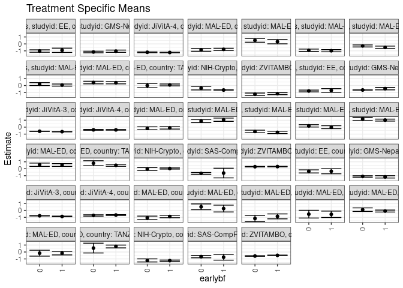

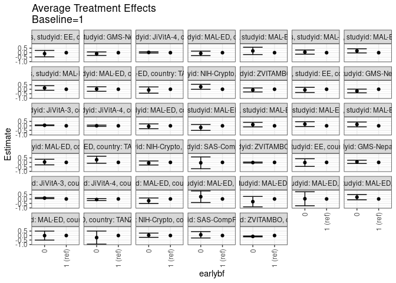

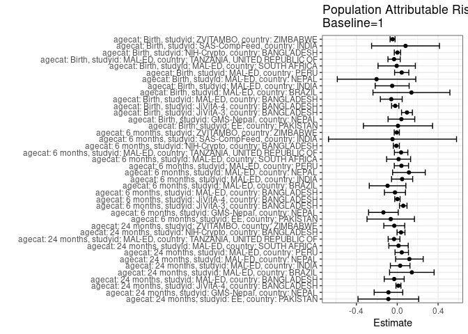

## Results Table

### Parameter: TSM

| agecat | studyid | country | intervention_level | baseline_level | estimate | ci_lower | ci_upper |
| --- | --- | --- | --- | --- | --- | --- | --- |
| Birth | EE | PAKISTAN | 1 | NA | -0.3595509 | -0.7214070 | 0.0023052 |
| Birth | EE | PAKISTAN | 0 | NA | -0.3811534 | -0.6036691 | -0.1586378 |
| Birth | GMS-Nepal | NEPAL | 1 | NA | -1.1668145 | -1.3328494 | -1.0007796 |
| Birth | GMS-Nepal | NEPAL | 0 | NA | -1.1063340 | -1.2101968 | -1.0024713 |
| Birth | JiVitA-3 | BANGLADESH | 1 | NA | -0.8730261 | -0.9236313 | -0.8224209 |
| Birth | JiVitA-3 | BANGLADESH | 0 | NA | -0.7773720 | -0.7968639 | -0.7578801 |
| Birth | JiVitA-4 | BANGLADESH | 1 | NA | -0.6687328 | -0.7280694 | -0.6093962 |
| Birth | JiVitA-4 | BANGLADESH | 0 | NA | -0.7310165 | -0.8280539 | -0.6339791 |
| Birth | MAL-ED | BANGLADESH | 1 | NA | -0.8805511 | -1.0583428 | -0.7027595 |
| Birth | MAL-ED | BANGLADESH | 0 | NA | -1.0796404 | -1.3348973 | -0.8243836 |
| Birth | MAL-ED | BRAZIL | 1 | NA | 0.2640571 | -0.2271700 | 0.7552842 |
| Birth | MAL-ED | BRAZIL | 0 | NA | 0.5124420 | 0.0961548 | 0.9287293 |
| Birth | MAL-ED | INDIA | 1 | NA | -0.8624464 | -1.2161770 | -0.5087157 |
| Birth | MAL-ED | INDIA | 0 | NA | -1.1635475 | -1.6160301 | -0.7110649 |
| Birth | MAL-ED | NEPAL | 1 | NA | -0.5656815 | -1.0277210 | -0.1036421 |
| Birth | MAL-ED | NEPAL | 0 | NA | -0.5433345 | -1.0992942 | 0.0126252 |
| Birth | MAL-ED | PERU | 1 | NA | -0.0956459 | -0.2346852 | 0.0433935 |
| Birth | MAL-ED | PERU | 0 | NA | 0.1028593 | -0.1526157 | 0.3583344 |
| Birth | MAL-ED | SOUTH AFRICA | 1 | NA | -0.1636103 | -0.4201511 | 0.0929304 |
| Birth | MAL-ED | SOUTH AFRICA | 0 | NA | -0.1709301 | -0.5967438 | 0.2548836 |
| Birth | MAL-ED | TANZANIA, UNITED REPUBLIC OF | 1 | NA | 0.7933946 | 0.5917219 | 0.9950673 |
| Birth | MAL-ED | TANZANIA, UNITED REPUBLIC OF | 0 | NA | 0.5625404 | -0.1398811 | 1.2649620 |
| Birth | NIH-Crypto | BANGLADESH | 1 | NA | -1.2460249 | -1.3361723 | -1.1558775 |
| Birth | NIH-Crypto | BANGLADESH | 0 | NA | -1.2119916 | -1.4334215 | -0.9905617 |
| Birth | SAS-CompFeed | INDIA | 1 | NA | -0.7487237 | -1.1696455 | -0.3278020 |
| Birth | SAS-CompFeed | INDIA | 0 | NA | -0.6673548 | -0.8346498 | -0.5000599 |
| Birth | ZVITAMBO | ZIMBABWE | 1 | NA | -0.4805131 | -0.5165799 | -0.4444463 |
| Birth | ZVITAMBO | ZIMBABWE | 0 | NA | -0.5785771 | -0.6166799 | -0.5404744 |
| 6 months | EE | PAKISTAN | 1 | NA | -0.7087545 | -0.9661626 | -0.4513464 |
| 6 months | EE | PAKISTAN | 0 | NA | -0.7833552 | -0.9103623 | -0.6563482 |
| 6 months | GMS-Nepal | NEPAL | 1 | NA | -0.4488380 | -0.6239707 | -0.2737053 |
| 6 months | GMS-Nepal | NEPAL | 0 | NA | -0.6417224 | -0.7493067 | -0.5341380 |
| 6 months | JiVitA-3 | BANGLADESH | 1 | NA | -0.6522508 | -0.6841071 | -0.6203946 |
| 6 months | JiVitA-3 | BANGLADESH | 0 | NA | -0.5933310 | -0.6133654 | -0.5732966 |
| 6 months | JiVitA-4 | BANGLADESH | 1 | NA | -0.3914783 | -0.4363538 | -0.3466028 |
| 6 months | JiVitA-4 | BANGLADESH | 0 | NA | -0.3860876 | -0.4467986 | -0.3253766 |
| 6 months | MAL-ED | BANGLADESH | 1 | NA | -0.1091385 | -0.2734693 | 0.0551923 |
| 6 months | MAL-ED | BANGLADESH | 0 | NA | -0.1659947 | -0.3792807 | 0.0472913 |
| 6 months | MAL-ED | BRAZIL | 1 | NA | 1.0668397 | 0.8317231 | 1.3019564 |
| 6 months | MAL-ED | BRAZIL | 0 | NA | 0.8828516 | 0.6547603 | 1.1109428 |
| 6 months | MAL-ED | INDIA | 1 | NA | -0.7556871 | -0.9258351 | -0.5855390 |
| 6 months | MAL-ED | INDIA | 0 | NA | -0.6213081 | -0.8097101 | -0.4329060 |
| 6 months | MAL-ED | NEPAL | 1 | NA | -0.0039790 | -0.2151217 | 0.2071637 |
| 6 months | MAL-ED | NEPAL | 0 | NA | 0.1832201 | 0.0168045 | 0.3496357 |
| 6 months | MAL-ED | PERU | 1 | NA | 1.0121538 | 0.8688682 | 1.1554395 |
| 6 months | MAL-ED | PERU | 0 | NA | 1.1671791 | 0.9407559 | 1.3936023 |
| 6 months | MAL-ED | SOUTH AFRICA | 1 | NA | 0.5367394 | 0.3358052 | 0.7376736 |
| 6 months | MAL-ED | SOUTH AFRICA | 0 | NA | 0.5751619 | 0.3368054 | 0.8135184 |
| 6 months | MAL-ED | TANZANIA, UNITED REPUBLIC OF | 1 | NA | 0.4984064 | 0.3554324 | 0.6413804 |
| 6 months | MAL-ED | TANZANIA, UNITED REPUBLIC OF | 0 | NA | 0.7920250 | 0.4308673 | 1.1531828 |
| 6 months | NIH-Crypto | BANGLADESH | 1 | NA | 0.0386586 | -0.0466069 | 0.1239242 |
| 6 months | NIH-Crypto | BANGLADESH | 0 | NA | -0.0287903 | -0.2367332 | 0.1791526 |
| 6 months | SAS-CompFeed | INDIA | 1 | NA | -0.6193063 | -1.3132515 | 0.0746389 |
| 6 months | SAS-CompFeed | INDIA | 0 | NA | -0.6679562 | -0.7976911 | -0.5382213 |
| 6 months | ZVITAMBO | ZIMBABWE | 1 | NA | 0.3117169 | 0.2751589 | 0.3482748 |
| 6 months | ZVITAMBO | ZIMBABWE | 0 | NA | 0.2957698 | 0.2548350 | 0.3367047 |
| 24 months | EE | PAKISTAN | 1 | NA | -0.9172617 | -1.2283917 | -0.6061316 |
| 24 months | EE | PAKISTAN | 0 | NA | -1.0240857 | -1.1967524 | -0.8514189 |
| 24 months | GMS-Nepal | NEPAL | 1 | NA | -1.0478346 | -1.2113042 | -0.8843651 |
| 24 months | GMS-Nepal | NEPAL | 0 | NA | -1.1616066 | -1.2740480 | -1.0491652 |
| 24 months | JiVitA-4 | BANGLADESH | 1 | NA | -1.2347012 | -1.2751177 | -1.1942846 |
| 24 months | JiVitA-4 | BANGLADESH | 0 | NA | -1.2043197 | -1.2608614 | -1.1477780 |
| 24 months | MAL-ED | BANGLADESH | 1 | NA | -0.7842870 | -0.9428900 | -0.6256841 |
| 24 months | MAL-ED | BANGLADESH | 0 | NA | -0.8624693 | -1.0582677 | -0.6666710 |
| 24 months | MAL-ED | BRAZIL | 1 | NA | 0.3196860 | 0.0116181 | 0.6277538 |
| 24 months | MAL-ED | BRAZIL | 0 | NA | 0.5163796 | 0.2412261 | 0.7915331 |
| 24 months | MAL-ED | INDIA | 1 | NA | -0.9802205 | -1.1370104 | -0.8234306 |
| 24 months | MAL-ED | INDIA | 0 | NA | -0.9151118 | -1.0878829 | -0.7423407 |
| 24 months | MAL-ED | NEPAL | 1 | NA | -0.4937505 | -0.6722088 | -0.3152921 |
| 24 months | MAL-ED | NEPAL | 0 | NA | -0.2906066 | -0.4359569 | -0.1452563 |
| 24 months | MAL-ED | PERU | 1 | NA | 0.0670859 | -0.0836824 | 0.2178543 |
| 24 months | MAL-ED | PERU | 0 | NA | 0.2064169 | 0.0013404 | 0.4114933 |
| 24 months | MAL-ED | SOUTH AFRICA | 1 | NA | 0.4028749 | 0.2410352 | 0.5647147 |
| 24 months | MAL-ED | SOUTH AFRICA | 0 | NA | 0.4286714 | 0.2433545 | 0.6139882 |
| 24 months | MAL-ED | TANZANIA, UNITED REPUBLIC OF | 1 | NA | 0.0862246 | -0.0486988 | 0.2211480 |
| 24 months | MAL-ED | TANZANIA, UNITED REPUBLIC OF | 0 | NA | -0.0022843 | -0.3231511 | 0.3185824 |
| 24 months | NIH-Crypto | BANGLADESH | 1 | NA | -0.6471417 | -0.7475236 | -0.5467598 |
| 24 months | NIH-Crypto | BANGLADESH | 0 | NA | -0.3739460 | -0.6333243 | -0.1145678 |
| 24 months | ZVITAMBO | ZIMBABWE | 1 | NA | -1.1676830 | -1.3111002 | -1.0242657 |
| 24 months | ZVITAMBO | ZIMBABWE | 0 | NA | -1.2488996 | -1.4175787 | -1.0802206 |

### Parameter: E(Y)

| agecat | studyid | country | intervention_level | baseline_level | estimate | ci_lower | ci_upper |
| --- | --- | --- | --- | --- | --- | --- | --- |
| Birth | EE | PAKISTAN | NA | NA | -0.3522059 | -0.5428560 | -0.1615557 |
| Birth | GMS-Nepal | NEPAL | NA | NA | -1.1260580 | -1.2184297 | -1.0336863 |
| Birth | JiVitA-3 | BANGLADESH | NA | NA | -0.7778811 | -0.7969145 | -0.7588476 |
| Birth | JiVitA-4 | BANGLADESH | NA | NA | -0.6886269 | -0.7410452 | -0.6362086 |
| Birth | MAL-ED | BANGLADESH | NA | NA | -0.9390654 | -1.0847642 | -0.7933666 |
| Birth | MAL-ED | BRAZIL | NA | NA | 0.4029032 | 0.0896793 | 0.7161272 |
| Birth | MAL-ED | INDIA | NA | NA | -0.9122727 | -1.1899971 | -0.6345483 |
| Birth | MAL-ED | NEPAL | NA | NA | -0.7684615 | -1.1257770 | -0.4111460 |
| Birth | MAL-ED | PERU | NA | NA | -0.0520175 | -0.1725298 | 0.0684947 |
| Birth | MAL-ED | SOUTH AFRICA | NA | NA | -0.1690000 | -0.3880340 | 0.0500340 |
| Birth | MAL-ED | TANZANIA, UNITED REPUBLIC OF | NA | NA | 0.7624348 | 0.5710709 | 0.9537986 |
| Birth | NIH-Crypto | BANGLADESH | NA | NA | -1.2441513 | -1.3281130 | -1.1601897 |
| Birth | SAS-CompFeed | INDIA | NA | NA | -0.6676026 | -0.8422097 | -0.4929956 |
| Birth | ZVITAMBO | ZIMBABWE | NA | NA | -0.5262098 | -0.5537283 | -0.4986913 |
| 6 months | EE | PAKISTAN | NA | NA | -0.7725778 | -0.8877440 | -0.6574117 |
| 6 months | GMS-Nepal | NEPAL | NA | NA | -0.5843738 | -0.6761994 | -0.4925481 |
| 6 months | JiVitA-3 | BANGLADESH | NA | NA | -0.5935161 | -0.6130518 | -0.5739805 |
| 6 months | JiVitA-4 | BANGLADESH | NA | NA | -0.3898055 | -0.4270507 | -0.3525603 |
| 6 months | MAL-ED | BANGLADESH | NA | NA | -0.1316250 | -0.2604010 | -0.0028490 |
| 6 months | MAL-ED | BRAZIL | NA | NA | 0.9720774 | 0.8078144 | 1.1363403 |
| 6 months | MAL-ED | INDIA | NA | NA | -0.7079979 | -0.8344175 | -0.5815783 |
| 6 months | MAL-ED | NEPAL | NA | NA | 0.1104308 | -0.0208643 | 0.2417259 |
| 6 months | MAL-ED | PERU | NA | NA | 1.0528816 | 0.9313005 | 1.1744626 |
| 6 months | MAL-ED | SOUTH AFRICA | NA | NA | 0.5500267 | 0.3964966 | 0.7035568 |
| 6 months | MAL-ED | TANZANIA, UNITED REPUBLIC OF | NA | NA | 0.5362213 | 0.4049390 | 0.6675036 |
| 6 months | NIH-Crypto | BANGLADESH | NA | NA | 0.0297622 | -0.0491685 | 0.1086930 |
| 6 months | SAS-CompFeed | INDIA | NA | NA | -0.6657084 | -0.8024377 | -0.5289791 |
| 6 months | ZVITAMBO | ZIMBABWE | NA | NA | 0.3072633 | 0.2799882 | 0.3345385 |
| 24 months | EE | PAKISTAN | NA | NA | -1.0044512 | -1.1543739 | -0.8545285 |
| 24 months | GMS-Nepal | NEPAL | NA | NA | -1.1339602 | -1.2266932 | -1.0412272 |
| 24 months | JiVitA-4 | BANGLADESH | NA | NA | -1.2231088 | -1.2549632 | -1.1912543 |
| 24 months | MAL-ED | BANGLADESH | NA | NA | -0.8141706 | -0.9363085 | -0.6920327 |
| 24 months | MAL-ED | BRAZIL | NA | NA | 0.4626233 | 0.2567495 | 0.6684971 |
| 24 months | MAL-ED | INDIA | NA | NA | -0.9516520 | -1.0670654 | -0.8362385 |
| 24 months | MAL-ED | NEPAL | NA | NA | -0.3749123 | -0.4886073 | -0.2612173 |
| 24 months | MAL-ED | PERU | NA | NA | 0.1111982 | -0.0118399 | 0.2342362 |
| 24 months | MAL-ED | SOUTH AFRICA | NA | NA | 0.4152943 | 0.2928804 | 0.5377083 |
| 24 months | MAL-ED | TANZANIA, UNITED REPUBLIC OF | NA | NA | 0.0547975 | -0.0703378 | 0.1799328 |
| 24 months | NIH-Crypto | BANGLADESH | NA | NA | -0.6103502 | -0.7050157 | -0.5156847 |
| 24 months | ZVITAMBO | ZIMBABWE | NA | NA | -1.1970712 | -1.3045749 | -1.0895676 |

### Parameter: ATE

| agecat | studyid | country | intervention_level | baseline_level | estimate | ci_lower | ci_upper |
| --- | --- | --- | --- | --- | --- | --- | --- |
| Birth | EE | PAKISTAN | 1 | 1 | 0.0000000 | 0.0000000 | 0.0000000 |
| Birth | EE | PAKISTAN | 0 | 1 | -0.0216025 | -0.4490635 | 0.4058585 |
| Birth | GMS-Nepal | NEPAL | 1 | 1 | 0.0000000 | 0.0000000 | 0.0000000 |
| Birth | GMS-Nepal | NEPAL | 0 | 1 | 0.0604805 | -0.1243650 | 0.2453260 |
| Birth | JiVitA-3 | BANGLADESH | 1 | 1 | 0.0000000 | 0.0000000 | 0.0000000 |
| Birth | JiVitA-3 | BANGLADESH | 0 | 1 | 0.0956541 | 0.0412853 | 0.1500229 |
| Birth | JiVitA-4 | BANGLADESH | 1 | 1 | 0.0000000 | 0.0000000 | 0.0000000 |
| Birth | JiVitA-4 | BANGLADESH | 0 | 1 | -0.0622837 | -0.1729399 | 0.0483725 |
| Birth | MAL-ED | BANGLADESH | 1 | 1 | 0.0000000 | 0.0000000 | 0.0000000 |
| Birth | MAL-ED | BANGLADESH | 0 | 1 | -0.1990893 | -0.5100877 | 0.1119091 |
| Birth | MAL-ED | BRAZIL | 1 | 1 | 0.0000000 | 0.0000000 | 0.0000000 |
| Birth | MAL-ED | BRAZIL | 0 | 1 | 0.2483849 | -0.3992792 | 0.8960490 |
| Birth | MAL-ED | INDIA | 1 | 1 | 0.0000000 | 0.0000000 | 0.0000000 |
| Birth | MAL-ED | INDIA | 0 | 1 | -0.3011012 | -0.8790096 | 0.2768072 |
| Birth | MAL-ED | NEPAL | 1 | 1 | 0.0000000 | 0.0000000 | 0.0000000 |
| Birth | MAL-ED | NEPAL | 0 | 1 | 0.0223470 | -0.7596330 | 0.8043270 |
| Birth | MAL-ED | PERU | 1 | 1 | 0.0000000 | 0.0000000 | 0.0000000 |
| Birth | MAL-ED | PERU | 0 | 1 | 0.1985052 | -0.0927313 | 0.4897418 |
| Birth | MAL-ED | SOUTH AFRICA | 1 | 1 | 0.0000000 | 0.0000000 | 0.0000000 |
| Birth | MAL-ED | SOUTH AFRICA | 0 | 1 | -0.0073198 | -0.5090998 | 0.4944602 |
| Birth | MAL-ED | TANZANIA, UNITED REPUBLIC OF | 1 | 1 | 0.0000000 | 0.0000000 | 0.0000000 |
| Birth | MAL-ED | TANZANIA, UNITED REPUBLIC OF | 0 | 1 | -0.2308541 | -0.9586171 | 0.4969089 |
| Birth | NIH-Crypto | BANGLADESH | 1 | 1 | 0.0000000 | 0.0000000 | 0.0000000 |
| Birth | NIH-Crypto | BANGLADESH | 0 | 1 | 0.0340333 | -0.2030629 | 0.2711295 |
| Birth | SAS-CompFeed | INDIA | 1 | 1 | 0.0000000 | 0.0000000 | 0.0000000 |
| Birth | SAS-CompFeed | INDIA | 0 | 1 | 0.0813689 | -0.2746785 | 0.4374163 |
| Birth | ZVITAMBO | ZIMBABWE | 1 | 1 | 0.0000000 | 0.0000000 | 0.0000000 |
| Birth | ZVITAMBO | ZIMBABWE | 0 | 1 | -0.0980640 | -0.1466102 | -0.0495179 |
| 6 months | EE | PAKISTAN | 1 | 1 | 0.0000000 | 0.0000000 | 0.0000000 |
| 6 months | EE | PAKISTAN | 0 | 1 | -0.0746007 | -0.3618672 | 0.2126658 |
| 6 months | GMS-Nepal | NEPAL | 1 | 1 | 0.0000000 | 0.0000000 | 0.0000000 |
| 6 months | GMS-Nepal | NEPAL | 0 | 1 | -0.1928844 | -0.3986813 | 0.0129125 |
| 6 months | JiVitA-3 | BANGLADESH | 1 | 1 | 0.0000000 | 0.0000000 | 0.0000000 |
| 6 months | JiVitA-3 | BANGLADESH | 0 | 1 | 0.0589198 | 0.0210947 | 0.0967450 |
| 6 months | JiVitA-4 | BANGLADESH | 1 | 1 | 0.0000000 | 0.0000000 | 0.0000000 |
| 6 months | JiVitA-4 | BANGLADESH | 0 | 1 | 0.0053907 | -0.0669758 | 0.0777572 |
| 6 months | MAL-ED | BANGLADESH | 1 | 1 | 0.0000000 | 0.0000000 | 0.0000000 |
| 6 months | MAL-ED | BANGLADESH | 0 | 1 | -0.0568562 | -0.3260625 | 0.2123501 |
| 6 months | MAL-ED | BRAZIL | 1 | 1 | 0.0000000 | 0.0000000 | 0.0000000 |
| 6 months | MAL-ED | BRAZIL | 0 | 1 | -0.1839882 | -0.5104363 | 0.1424600 |
| 6 months | MAL-ED | INDIA | 1 | 1 | 0.0000000 | 0.0000000 | 0.0000000 |
| 6 months | MAL-ED | INDIA | 0 | 1 | 0.1343790 | -0.1199795 | 0.3887375 |
| 6 months | MAL-ED | NEPAL | 1 | 1 | 0.0000000 | 0.0000000 | 0.0000000 |
| 6 months | MAL-ED | NEPAL | 0 | 1 | 0.1871991 | -0.0802547 | 0.4546529 |
| 6 months | MAL-ED | PERU | 1 | 1 | 0.0000000 | 0.0000000 | 0.0000000 |
| 6 months | MAL-ED | PERU | 0 | 1 | 0.1550252 | -0.1124137 | 0.4224642 |
| 6 months | MAL-ED | SOUTH AFRICA | 1 | 1 | 0.0000000 | 0.0000000 | 0.0000000 |
| 6 months | MAL-ED | SOUTH AFRICA | 0 | 1 | 0.0384225 | -0.2743877 | 0.3512327 |
| 6 months | MAL-ED | TANZANIA, UNITED REPUBLIC OF | 1 | 1 | 0.0000000 | 0.0000000 | 0.0000000 |
| 6 months | MAL-ED | TANZANIA, UNITED REPUBLIC OF | 0 | 1 | 0.2936186 | -0.0987121 | 0.6859494 |
| 6 months | NIH-Crypto | BANGLADESH | 1 | 1 | 0.0000000 | 0.0000000 | 0.0000000 |
| 6 months | NIH-Crypto | BANGLADESH | 0 | 1 | -0.0674490 | -0.2919436 | 0.1570457 |
| 6 months | SAS-CompFeed | INDIA | 1 | 1 | 0.0000000 | 0.0000000 | 0.0000000 |
| 6 months | SAS-CompFeed | INDIA | 0 | 1 | -0.0486499 | -0.7072480 | 0.6099483 |
| 6 months | ZVITAMBO | ZIMBABWE | 1 | 1 | 0.0000000 | 0.0000000 | 0.0000000 |
| 6 months | ZVITAMBO | ZIMBABWE | 0 | 1 | -0.0159470 | -0.0703198 | 0.0384258 |
| 24 months | EE | PAKISTAN | 1 | 1 | 0.0000000 | 0.0000000 | 0.0000000 |
| 24 months | EE | PAKISTAN | 0 | 1 | -0.1068240 | -0.4650728 | 0.2514248 |
| 24 months | GMS-Nepal | NEPAL | 1 | 1 | 0.0000000 | 0.0000000 | 0.0000000 |
| 24 months | GMS-Nepal | NEPAL | 0 | 1 | -0.1137720 | -0.3124360 | 0.0848921 |
| 24 months | JiVitA-4 | BANGLADESH | 1 | 1 | 0.0000000 | 0.0000000 | 0.0000000 |
| 24 months | JiVitA-4 | BANGLADESH | 0 | 1 | 0.0303815 | -0.0392069 | 0.0999698 |
| 24 months | MAL-ED | BANGLADESH | 1 | 1 | 0.0000000 | 0.0000000 | 0.0000000 |
| 24 months | MAL-ED | BANGLADESH | 0 | 1 | -0.0781823 | -0.3293007 | 0.1729361 |
| 24 months | MAL-ED | BRAZIL | 1 | 1 | 0.0000000 | 0.0000000 | 0.0000000 |
| 24 months | MAL-ED | BRAZIL | 0 | 1 | 0.1966936 | -0.2126039 | 0.6059912 |
| 24 months | MAL-ED | INDIA | 1 | 1 | 0.0000000 | 0.0000000 | 0.0000000 |
| 24 months | MAL-ED | INDIA | 0 | 1 | 0.0651087 | -0.1687060 | 0.2989234 |
| 24 months | MAL-ED | NEPAL | 1 | 1 | 0.0000000 | 0.0000000 | 0.0000000 |
| 24 months | MAL-ED | NEPAL | 0 | 1 | 0.2031439 | -0.0266538 | 0.4329415 |
| 24 months | MAL-ED | PERU | 1 | 1 | 0.0000000 | 0.0000000 | 0.0000000 |
| 24 months | MAL-ED | PERU | 0 | 1 | 0.1393309 | -0.1163434 | 0.3950052 |
| 24 months | MAL-ED | SOUTH AFRICA | 1 | 1 | 0.0000000 | 0.0000000 | 0.0000000 |
| 24 months | MAL-ED | SOUTH AFRICA | 0 | 1 | 0.0257964 | -0.2194381 | 0.2710310 |
| 24 months | MAL-ED | TANZANIA, UNITED REPUBLIC OF | 1 | 1 | 0.0000000 | 0.0000000 | 0.0000000 |
| 24 months | MAL-ED | TANZANIA, UNITED REPUBLIC OF | 0 | 1 | -0.0885090 | -0.4361377 | 0.2591198 |
| 24 months | NIH-Crypto | BANGLADESH | 1 | 1 | 0.0000000 | 0.0000000 | 0.0000000 |
| 24 months | NIH-Crypto | BANGLADESH | 0 | 1 | 0.2731957 | -0.0028923 | 0.5492836 |
| 24 months | ZVITAMBO | ZIMBABWE | 1 | 1 | 0.0000000 | 0.0000000 | 0.0000000 |
| 24 months | ZVITAMBO | ZIMBABWE | 0 | 1 | -0.0812167 | -0.3032607 | 0.1408273 |

### Parameter: PAR

| agecat | studyid | country | intervention_level | baseline_level | estimate | ci_lower | ci_upper |
| --- | --- | --- | --- | --- | --- | --- | --- |
| Birth | EE | PAKISTAN | 1 | NA | 0.0073451 | -0.3313554 | 0.3460455 |
| Birth | GMS-Nepal | NEPAL | 1 | NA | 0.0407565 | -0.0899791 | 0.1714921 |
| Birth | JiVitA-3 | BANGLADESH | 1 | NA | 0.0951451 | 0.0421283 | 0.1481618 |
| Birth | JiVitA-4 | BANGLADESH | 1 | NA | -0.0198941 | -0.0556916 | 0.0159035 |
| Birth | MAL-ED | BANGLADESH | 1 | NA | -0.0585143 | -0.1653422 | 0.0483136 |
| Birth | MAL-ED | BRAZIL | 1 | NA | 0.1388461 | -0.2378822 | 0.5155744 |
| Birth | MAL-ED | INDIA | 1 | NA | -0.0498264 | -0.2161406 | 0.1164879 |
| Birth | MAL-ED | NEPAL | 1 | NA | -0.2027800 | -0.5869271 | 0.1813671 |
| Birth | MAL-ED | PERU | 1 | NA | 0.0436283 | -0.0260275 | 0.1132841 |
| Birth | MAL-ED | SOUTH AFRICA | 1 | NA | -0.0053897 | -0.1882126 | 0.1774333 |
| Birth | MAL-ED | TANZANIA, UNITED REPUBLIC OF | 1 | NA | -0.0309598 | -0.0911048 | 0.0291852 |
| Birth | NIH-Crypto | BANGLADESH | 1 | NA | 0.0018736 | -0.0291179 | 0.0328650 |
| Birth | SAS-CompFeed | INDIA | 1 | NA | 0.0811211 | -0.2512352 | 0.4134774 |
| Birth | ZVITAMBO | ZIMBABWE | 1 | NA | -0.0456968 | -0.0700262 | -0.0213673 |
| 6 months | EE | PAKISTAN | 1 | NA | -0.0638233 | -0.2960289 | 0.1683823 |
| 6 months | GMS-Nepal | NEPAL | 1 | NA | -0.1355358 | -0.2810742 | 0.0100026 |
| 6 months | JiVitA-3 | BANGLADESH | 1 | NA | 0.0587347 | 0.0218379 | 0.0956314 |
| 6 months | JiVitA-4 | BANGLADESH | 1 | NA | 0.0016728 | -0.0244879 | 0.0278335 |
| 6 months | MAL-ED | BANGLADESH | 1 | NA | -0.0224865 | -0.1257356 | 0.0807626 |
| 6 months | MAL-ED | BRAZIL | 1 | NA | -0.0947624 | -0.2741161 | 0.0845913 |
| 6 months | MAL-ED | INDIA | 1 | NA | 0.0476892 | -0.0558226 | 0.1512010 |
| 6 months | MAL-ED | NEPAL | 1 | NA | 0.1144098 | -0.0454145 | 0.2742341 |
| 6 months | MAL-ED | PERU | 1 | NA | 0.0407277 | -0.0290343 | 0.1104898 |
| 6 months | MAL-ED | SOUTH AFRICA | 1 | NA | 0.0132873 | -0.1042322 | 0.1308068 |
| 6 months | MAL-ED | TANZANIA, UNITED REPUBLIC OF | 1 | NA | 0.0378149 | -0.0278875 | 0.1035173 |
| 6 months | NIH-Crypto | BANGLADESH | 1 | NA | -0.0088964 | -0.0386071 | 0.0208143 |
| 6 months | SAS-CompFeed | INDIA | 1 | NA | -0.0464021 | -0.6732477 | 0.5804435 |
| 6 months | ZVITAMBO | ZIMBABWE | 1 | NA | -0.0044535 | -0.0297065 | 0.0207995 |
| 24 months | EE | PAKISTAN | 1 | NA | -0.0871896 | -0.3844629 | 0.2100838 |
| 24 months | GMS-Nepal | NEPAL | 1 | NA | -0.0861256 | -0.2262199 | 0.0539688 |
| 24 months | JiVitA-4 | BANGLADESH | 1 | NA | 0.0115924 | -0.0128799 | 0.0360648 |
| 24 months | MAL-ED | BANGLADESH | 1 | NA | -0.0298836 | -0.1277680 | 0.0680008 |
| 24 months | MAL-ED | BRAZIL | 1 | NA | 0.1429373 | -0.0752417 | 0.3611163 |
| 24 months | MAL-ED | INDIA | 1 | NA | 0.0285685 | -0.0673543 | 0.1244914 |
| 24 months | MAL-ED | NEPAL | 1 | NA | 0.1188382 | -0.0162513 | 0.2539277 |
| 24 months | MAL-ED | PERU | 1 | NA | 0.0441122 | -0.0216523 | 0.1098768 |
| 24 months | MAL-ED | SOUTH AFRICA | 1 | NA | 0.0124194 | -0.0824557 | 0.1072945 |
| 24 months | MAL-ED | TANZANIA, UNITED REPUBLIC OF | 1 | NA | -0.0314271 | -0.0888250 | 0.0259708 |
| 24 months | NIH-Crypto | BANGLADESH | 1 | NA | 0.0367915 | -0.0018748 | 0.0754579 |
| 24 months | ZVITAMBO | ZIMBABWE | 1 | NA | -0.0293883 | -0.1317800 | 0.0730034 |